# Peer Assessmet 2 - which natural events impact health and economy in the United States

Soumya Das Bhaumik

May 22, 2015

## Synopsis

This report analyzes storms and severe weather events in the U.S.A. based on their health and economic impact to give an assessment of which events cause the highest economic impact and health impact. The **Data Analysis** section describes in detail the steps taken to analyze the data, from loading the raw data to processing it for the assessment. The **Results** section covers the findings, which indicate that **Tornadoes** by far have the highest impact from the perspective of population health as well as economy.

## Data Analysis

The analysis has been done on the U.S. National Oceanic and Atmospheric Administration’s (NOAA) storm database, which has been downloaded from the following location on May 22, 2015 at 10:01 PM EST:  
https://d396qusza40orc.cloudfront.net/repdata%2Fdata%2FStormData.csv.bz2  
The downloaded csv.bz2 file needs to be placed in a subdirectory called **Data**

```r
# load the raw data
stormDataRaw = read.csv("data/repdata-data-StormData.csv.bz2")
```

We now modify the property and crop damage colums so that they can be mathematically compared. This means multiplying elements of the PROPDMG (or CROPDMG) column by 1000 or 1 million depending on the string ‘K’ or ‘M’ respectively in the PROPDMGEXP (or CROPDMGEXP) column.

```r
# this function returns the corresponding number for 'K' or 'M'
getMultiplierForEXP <- function(expString)
{
    multiplier = 1
    if (expString == "K")
    {
        multiplier = 1000
    }
    else if (expString == "M")
    {
        multiplier = 1000000
    }
    multiplier
}

# update the property damage and crop damage columns to have the same unit
# so that we can do statistical computations on them
stormDataRaw$PROPDMGEXP = sapply(stormDataRaw$PROPDMGEXP, getMultiplierForEXP)
stormDataRaw$CROPDMGEXP = sapply(stormDataRaw$CROPDMGEXP, getMultiplierForEXP)

stormDataRaw$PROPDMG = stormDataRaw$PROPDMG * stormDataRaw$PROPDMGEXP
stormDataRaw$CROPDMG = stormDataRaw$CROPDMG * stormDataRaw$CROPDMGEXP
```

The data is then reshaped to be indexed on the event type.

```r
library(reshape2)
# reshape and cast the data based on event type
stormDataBasedOnType = melt(stormDataRaw, id="EVTYPE",
                            measure.vars = c("FATALITIES", "INJURIES",
                                             "PROPDMG", "CROPDMG"))
stormNetImpactBasedOnType = dcast(stormDataBasedOnType, EVTYPE ~ variable, sum)
```

Now that we have the data summed and categorized by storm type, we work on answering the questions:

1. Across the United States, which types of events (as indicated in the EVTYPE variable) are most harmful with respect to population health?

For this, we use the fatalities and injuries columns. We just add the two data points for each event type to get a total impact to population health for each event. We compute the max and also prepare the data for a graph which will be shared in the results section. That graph will include the top 25 impacting events

```r
stormNetImpactBasedOnType$HealthImpact = stormNetImpactBasedOnType$FATALITIES +
                                            stormNetImpactBasedOnType$INJURIES

# compute which event has the highest health impact
maxIdx = which.max(stormNetImpactBasedOnType$HealthImpact)
maxStormType = stormNetImpactBasedOnType[maxIdx,"EVTYPE"]

# prepare dataset for graphical representation.
stormHealthImpactForPlot = stormNetImpactBasedOnType[
                            with(stormNetImpactBasedOnType,
                                 order(-HealthImpact)),]

stormHealthImpactForPlot = stormHealthImpactForPlot[1:25,]
```

2. Across the United States, which types of events have the greatest economic consequences?

For this, we use the PROPDMG and CROPDMG columns. We just add the two data points for each event type to get a total impact to the economy for each event. Even here, we prepare the data for graphical representation. For the graph, we just consider the top 25 impacting events.

```r
stormNetImpactBasedOnType$EconImpact = stormNetImpactBasedOnType$PROPDMG +
                                        stormNetImpactBasedOnType$CROPDMG

# compute which event had the maximum economic impact
maxEcon = which.max(stormNetImpactBasedOnType$EconImpact)
maxStormEcon = stormNetImpactBasedOnType[maxEcon, "EVTYPE"]

# prepare the dataset for graphical representation
stormEconImpactForPlot = stormNetImpactBasedOnType[
                            with(stormNetImpactBasedOnType,
                                 order(-EconImpact)),]

stormEconImpactForPlot = stormEconImpactForPlot[1:25,]
```

## Results

The results of the analysis are presented here

### Natural events with the highest health impact

Here is are the results for which types of events are the most harmful with respect to population health

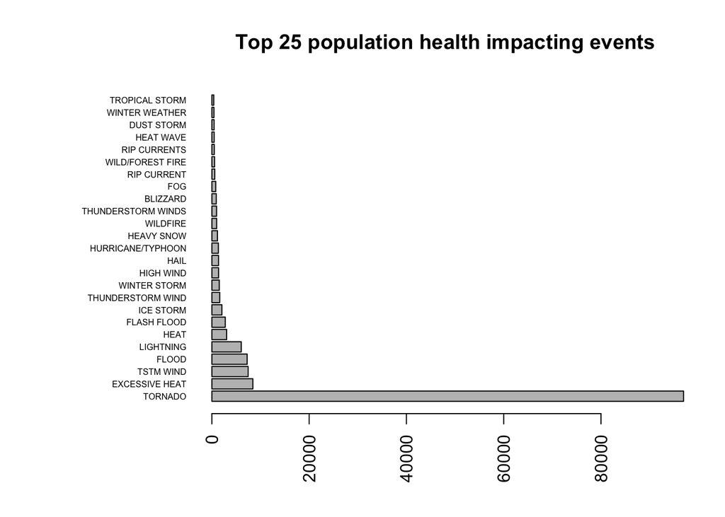

```r
par(las=2)
par(mar=c(5,10,4,2))
barplot(stormHealthImpactForPlot$HealthImpact,
        names.arg = stormHealthImpactForPlot$EVTYPE,
        horiz = TRUE, cex.names = 0.5,
        main = "Top 25 population health impacting events")
```

The bar plot includes the top 25 events base on health impact. From the graph, it is clear that **Tornadoes** have the most significant impact on population health and it exceeds the next most impactful event by over an order of magnitude

### Natural events with the highest econmic impact

Here are the results for which types of events are the most harmful with respect to the economy

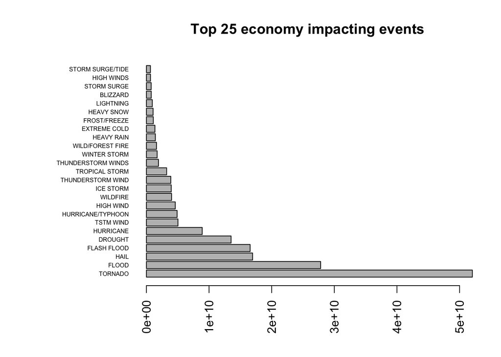

```r
par(las=2)
par(mar=c(5,10,4,2))
barplot(stormEconImpactForPlot$EconImpact,
        names.arg = stormEconImpactForPlot$EVTYPE,
        horiz=TRUE, cex.names=0.5,
        main = "Top 25 economy impacting events")
```